# Entrega_Colgate

Matias Corredoira

19/11/2020

#### Supuesto

Nuestro deseo es conocer la efectividad de los gastos en publicidad. Para conocer el impacto de las iniciativas tomadas se realizará el análisis de intervención. Para nuestro caso se tendrá en cuenta la lucha por mayores cuotas de mercados desde la perspectiva de dos empresas: Colgate y Crest.

### Cargamos las librerías necesarias.

### Indicamos la base de datos

```r
library(readxl)
data <- read_excel('data.xlsx')
View(data)
```

### IndICamos datos semanales y a continuación realizamos un pequeño sumatorio general de datos

```r
data$Date <- as.Date(paste(data$Year, data$Week, 1, sep = "-"), "%Y-%U-%u")
data <- dplyr::select(data, -Year, -Week)
```

Data summary

| Name | data |
| --- | --- |
| Number of rows | 276 |
| Number of columns | 3 |
| _______________________ |  |
| Column type frequency: |  |
| Date | 1 |
| numeric | 2 |
| ________________________ |  |
| Group variables | None |

**Variable type: Date**

| skim_variable | n_missing | complete_rate | min | max | median | n_unique |
| --- | --- | --- | --- | --- | --- | --- |
| Date | 0 | 1 | 1958-01-06 | 1963-04-22 | 1960-08-25 | 276 |

**Variable type: numeric**

| skim_variable | n_missing | complete_rate | mean | sd | p0 | p25 | p50 | p75 | p100 | hist |
| --- | --- | --- | --- | --- | --- | --- | --- | --- | --- | --- |
| Crest | 0 | 1 | 0.26 | 0.13 | 0.05 | 0.13 | 0.25 | 0.37 | 0.53 | ▇▅▃▇▂ |
| Colgate | 0 | 1 | 0.31 | 0.07 | 0.16 | 0.26 | 0.31 | 0.36 | 0.50 | ▂▇▇▅▁ |

### Separamos los datos tanto de Colgate como de Crest.

```r
colgate <- ts(data$Colgate, start=1958,frequency = 52)
crest <- ts(data$Crest, start = 1958, frequency =52)
```

### Convertimos los datos a formato zoo dado que queremos trabajar con series temporales. A continuación representamos las series.

```r
acolgate <- as.zoo(colgate)
acrest <- as.zoo(crest)
```

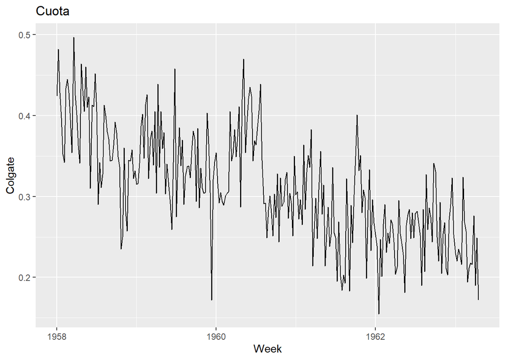

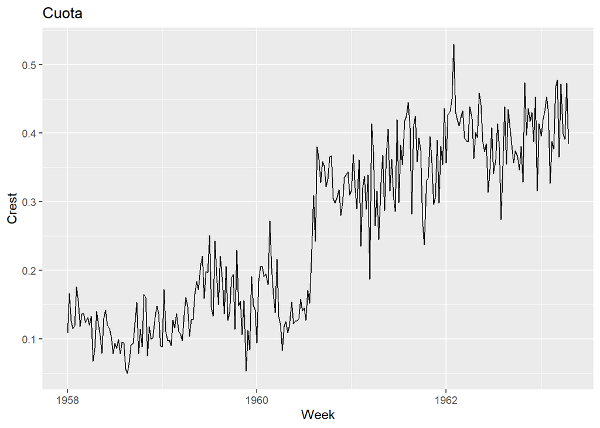

### A continuación mediante el test Dickey Fuller comprobaremos la posible existencia de estacionalidad dentro en las series.

```r
adf.test(acolgate)
```

```
##
##  Augmented Dickey-Fuller Test
##
## data:  acolgate
## Dickey-Fuller = -4.1783, Lag order = 6, p-value = 0.01
## alternative hypothesis: stationary
```

```r
adf.test(acrest)
```

```
##
##  Augmented Dickey-Fuller Test
##
## data:  acrest
## Dickey-Fuller = -3.4715, Lag order = 6, p-value = 0.04591
## alternative hypothesis: stationary
```

Ninguno de los 2 valores supera el margen de significación marcado, por lo que se concluye la existencia de estacionaridad.

### Eliminamos las semanas correspondientes al año 1963 las cuales formarán parte de nuestro test

```r
cOmit=16                             #Formarán parte del test

nObsColgate=length(acolgate)
nObsCrest= length(acrest)
```

Correspondientes a los meses pautados para la entrega.

### Seleccionamos el train de cada una de las 2 empresas.

```r
colgatet <- window(acolgate, start=index(acolgate[1]),end = index(acolgate[nObsColgate- cOmit]))
crestt <- window(acrest, star= index(acrest[1]), end = index(acrest[nObsCrest-cOmit]))
```

## Modelo ARIMA

#### Para obtener el modelo autilizaremos autoarima. Lo realizaremos con ela parte del train que hemos elaborado anteriormente.

```
## Series: colgatet
## ARIMA(0,1,1)(1,0,0)[52]
##
## Coefficients:
##           ma1    sar1
##       -0.7571  0.0232
## s.e.   0.0470  0.0682
##
## sigma^2 estimated as 0.00232:  log likelihood=418.63
## AIC=-831.25   AICc=-831.16   BIC=-820.58
##
## Training set error measures:
##                        ME       RMSE        MAE       MPE     MAPE      MASE
## Training set -0.002534821 0.04788855 0.03773876 -3.019377 12.77398 0.6038201
##                    ACF1
## Training set 0.05216089
```

```
## Series: crestt
## ARIMA(0,1,1)
##
## Coefficients:
##           ma1
##       -0.6494
## s.e.   0.0448
##
## sigma^2 estimated as 0.002054:  log likelihood=434.08
## AIC=-864.15   AICc=-864.1   BIC=-857.04
##
## Training set error measures:
##                       ME       RMSE        MAE       MPE     MAPE      MASE
## Training set 0.003018071 0.04514444 0.03445351 -2.924537 17.27068 0.3800355
##                     ACF1
## Training set -0.04605961
```

#### Comprobamos los residuos los residuos

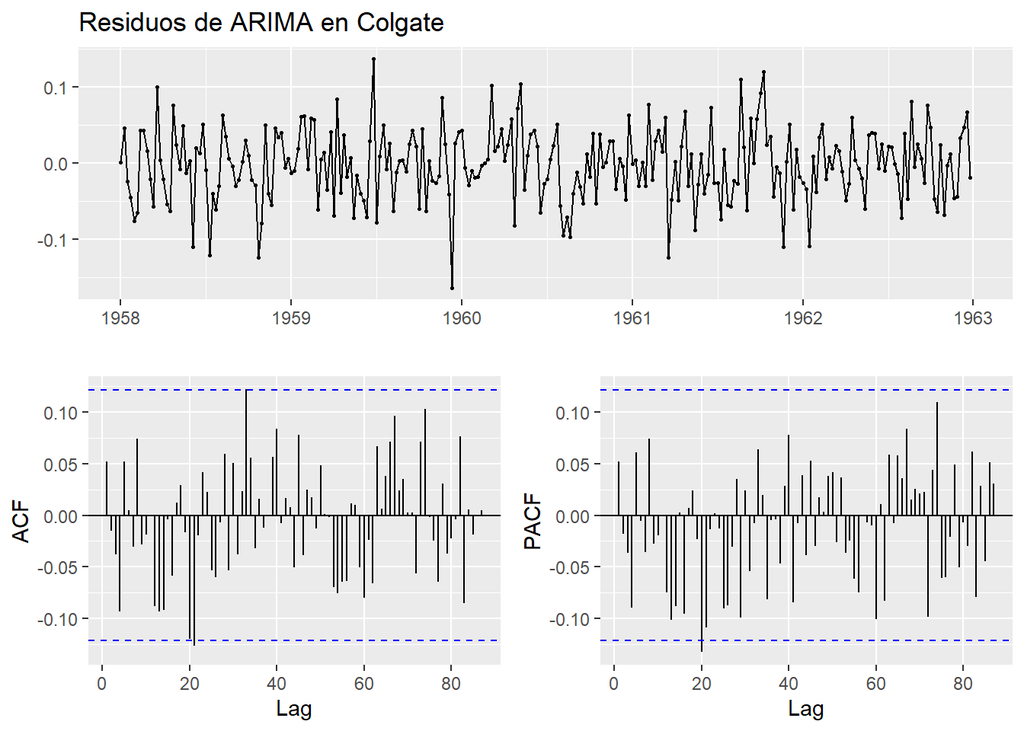

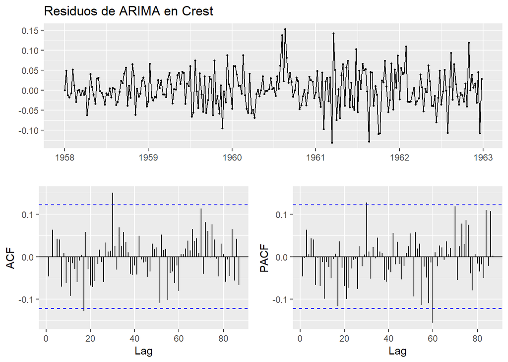

### Realizaremos el test de Box Ljung para la comprobación de la existencia de correlaciones dentro de las series temporales

```r
#box-Ljung Test
Box.test(fit_colgate$residuals,lag=3, fitdf=1, type="Lj")
```

```
##
##  Box-Ljung test
##
## data:  fit_colgate$residuals
## X-squared = 1.1567, df = 2, p-value = 0.5608
```

```r
Box.test(fit_crest$residuals,lag=3, fitdf=1, type="Lj")
```

```
##
##  Box-Ljung test
##
## data:  fit_crest$residuals
## X-squared = 1.6314, df = 2, p-value = 0.4423
```

Vemos como ambos valores nos dan por encima del nivel de significación, por lo que concluimos que la hipotesis nula no se rechaza, y por ello no rechazamos la independencia de las observaciones.

## Predicción

### Realizamos sus gráficos correspondientes, el primero con Colgate y el siguiente con Crest.

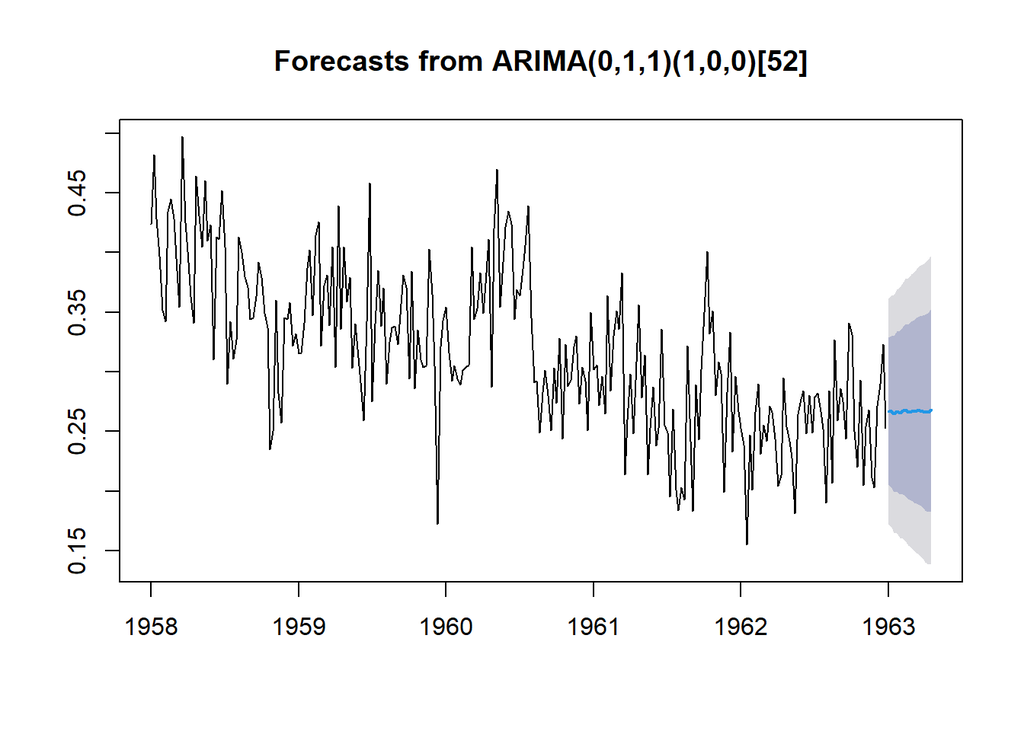

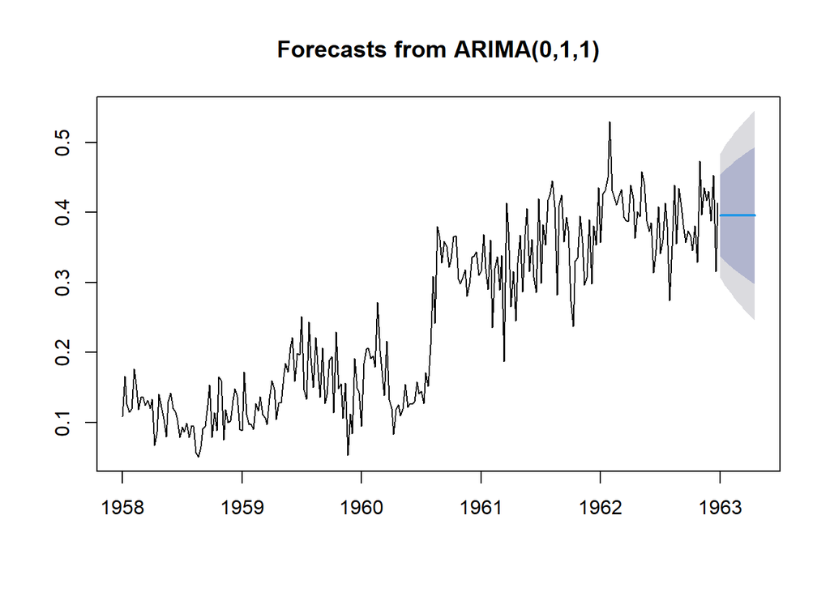

### Realizamos la localización de los distintos outliers en los modelos ARIMA realizados anteriormente.

```
## [1] "No AO detected"
```

```
##               [,1]       [,2]       [,3]
## ind     135.000000 136.000000 138.000000
## lambda2   3.918954   4.372891   4.005427
```

```
## [1] "No IO detected"
```

```
## [1] "No IO detected"
```

Comprobamos la existencia de tres outliers aditivos, en 135, dado por el comunicado, y en 136 y 138 que salen muy próximos al anterior suceso comentado.

## ARIMAX

#### Reaalizamos este modelo con el orden que nos ha proporcionado el anterior ARIMA con ambas empresas.

```
##
## Call:
## arimax(x = as.double(acolgate), order = c(0, 1, 1), method = "ML", xtransf = data.frame(A60_step = 1 *
##     (seq(acolgate)), A60_pulse = 1 * (seq(acolgate))), transfer = list(c(0,
##     0), c(1, 0)))
##
## Coefficients:
```

```
##           ma1  A60_step-MA0  A60_pulse-AR1  A60_pulse-MA0
##       -0.7730        -4e-04              0        -0.0004
## s.e.   0.0455           NaN            NaN         0.0072
##
## sigma^2 estimated as 0.002256:  log likelihood = 447.31,  aic = -886.61
```

```
##
## Call:
## arimax(x = as.double(acrest), order = c(0, 1, 1), xreg = data.frame(A60_3 = 1 *
##     (seq(acrest) == 136), A60_3 = 1 * (seq(acrest) == 138)), method = "ML",
##     xtransf = data.frame(A60_step = 1 * (seq(acrest) >= 135), A60_pulse = 1 *
##         (seq(acrest))), transfer = list(c(0, 0), c(0, 0)))
##
## Coefficients:
##           ma1   A60_3  A60_3.1  A60_step-MA0  A60_pulse-MA0
##       -0.7674  0.0205   0.0766        0.1346          5e-04
## s.e.   0.0476  0.0436   0.0420        0.0318          6e-04
##
## sigma^2 estimated as 0.001899:  log likelihood = 470.97,  aic = -931.94
```

#### De nuevo comprobamos la existencia de outliers, con la realización del ARIMAX vemos que ya no nos da ninguno.

```
## [1] "No AO detected"
```

```
## [1] "No IO detected"
```

```
## [1] "No AO detected"
```

```
## [1] "No IO detected"
```

#### Finalmente realizamos la función de transferencia.

```
##
## Call:
## arimax(x = as.double(acolgate), order = c(0, 1, 1), include.mean = TRUE, method = "ML",
##     xtransf = acrest, transfer = list(c(0, 0)))
##
## Coefficients:
##           ma1  xtransf-MA0
##       -0.8381      -0.4884
## s.e.   0.0346       0.0530
##
## sigma^2 estimated as 0.001751:  log likelihood = 481.99,  aic = -959.97
##
## Training set error measures:
##                       ME      RMSE        MAE       MPE     MAPE      MASE
## Training set -0.00136496 0.0417676 0.03229819 -2.196369 10.97291 0.6993702
##                    ACF1
## Training set 0.06132245
```

```r
transferenciacrest <- arimax(as.double(acrest),
                        order = c(0,1,1),
                        include.mean = TRUE,
                        xtransf = acolgate,
                        transfer = list(c(0,0)),
                        method = "ML")


summary(transferenciacrest)
```

```
##
## Call:
## arimax(x = as.double(acrest), order = c(0, 1, 1), include.mean = TRUE, method = "ML",
##     xtransf = acolgate, transfer = list(c(0, 0)))
##
## Coefficients:
##           ma1  xtransf-MA0
##       -0.7129      -0.4350
## s.e.   0.0415       0.0526
##
## sigma^2 estimated as 0.001653:  log likelihood = 490.12,  aic = -976.23
##
## Training set error measures:
##                       ME       RMSE        MAE       MPE     MAPE      MASE
## Training set 0.002513135 0.04058777 0.03171038 -2.585475 16.42409 0.7452021
##                     ACF1
## Training set -0.02762795
```

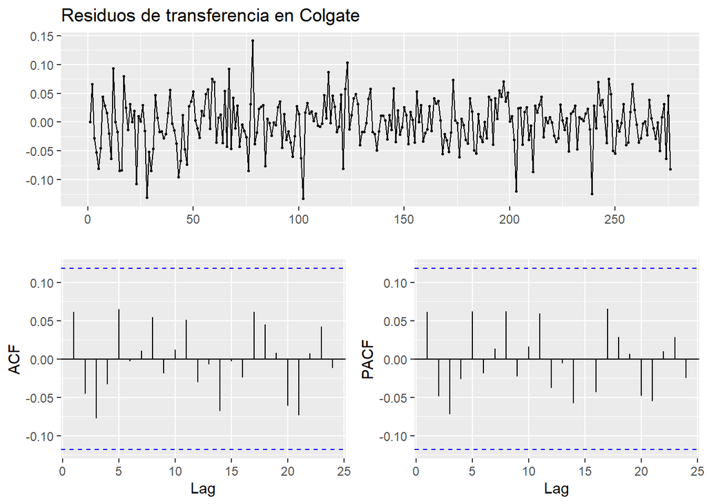

```r
ggtsdisplay(transferenciacolgate$residuals,
            main = "Residuos de transferencia en Colgate")
```

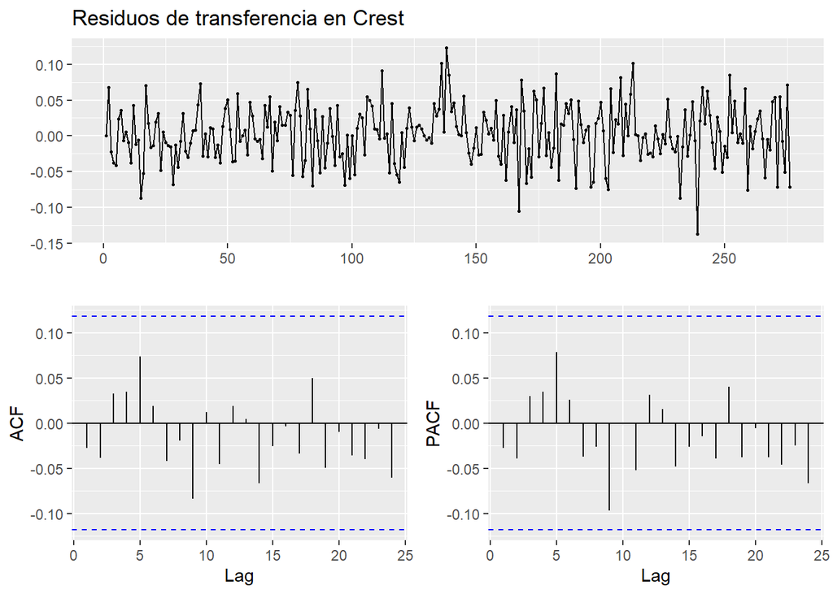

```r
ggtsdisplay(transferenciacrest$residuals,
            main = "Residuos de transferencia en Crest")
```

Como podemos comprobar con la función de transferencia todos los residuos son ruido blanco.